# Stephanie Lab2

Stephanie Gluck

4/18/2020

```r
library(tidyverse)
#install.packages("repurrrsive")
library(repurrrsive)
library(httr)
```

This lab will be similar to Lab 1 but will focus specifically on looping with {purrr}.

# Part A: Multiple Models

## Run the code below to load the following dataset.

```r
file <- "https://github.com/datalorax/esvis/raw/master/data/benchmarks.rda"
load(url(file))
head(benchmarks)
```

```
##      sid cohort     sped  ethnicity     frl     ell season reading math
## 1 332347      1 Non-Sped Native Am. Non-FRL Non-ELL Winter     208  205
## 2 400047      1 Non-Sped Native Am.     FRL Non-ELL Spring     212  218
## 3 402107      1 Non-Sped      White Non-FRL Non-ELL Winter     201  212
## 4 402547      1 Non-Sped      White Non-FRL Non-ELL   Fall     185  177
## 5 403047      1     Sped   Hispanic     FRL  Active Winter     179  192
## 6 403307      1     Sped   Hispanic Non-FRL Non-ELL Winter     189  188
```

## Recode season to wave with the following code

```r
benchmarks <- benchmarks %>%
    as_tibble() %>%
    mutate(wave = case_when(season == "Fall" ~ 0,
                            season == "Winter" ~ 1,
                            TRUE ~ 2))
benchmarks
```

```
## # A tibble: 3,731 x 10
##       sid cohort sped     ethnicity  frl     ell     season reading  math  wave
##     <dbl>  <dbl> <chr>    <chr>      <chr>   <chr>   <chr>    <dbl> <dbl> <dbl>
##  1 332347      1 Non-Sped Native Am. Non-FRL Non-ELL Winter     208   205     1
##  2 400047      1 Non-Sped Native Am. FRL     Non-ELL Spring     212   218     2
##  3 402107      1 Non-Sped White      Non-FRL Non-ELL Winter     201   212     1
##  4 402547      1 Non-Sped White      Non-FRL Non-ELL Fall       185   177     0
##  5 403047      1 Sped     Hispanic   FRL     Active  Winter     179   192     1
##  6 403307      1 Sped     Hispanic   Non-FRL Non-ELL Winter     189   188     1
##  7 404977      1 Non-Sped Hispanic   FRL     Monitor Winter     199   180     1
##  8 405107      1 Sped     Hispanic   Non-FRL Non-ELL Winter     168   177     1
##  9 405367      1 Non-Sped White      FRL     Non-ELL Spring     197   201     2
## 10 405367      1 Non-Sped White      Non-FRL Non-ELL Winter     203   203     1
## # ... with 3,721 more rows
```

## Fit a model of the form lm(math ~ wave) for each student.

```r
stu_split <- split(benchmarks, benchmarks$sid)

mods <- map(stu_split, ~lm(math ~ wave, data = .x))

#print the first 3 model
mods[1:3]
```

```
## $`332347`
##
## Call:
## lm(formula = math ~ wave, data = .x)
##
## Coefficients:
## (Intercept)         wave
##         205           NA
##
##
## $`400047`
##
## Call:
## lm(formula = math ~ wave, data = .x)
##
## Coefficients:
## (Intercept)         wave
##         218           NA
##
##
## $`402107`
##
## Call:
## lm(formula = math ~ wave, data = .x)
##
## Coefficients:
## (Intercept)         wave
##         212           NA
```

## Plot the distribution of slopes. Annotate the plot with a vertical line for the mean.

```r
coefs <- map(mods, ~coef(.x))

#simplify version, since only one function
#coefs <- map(mods, coef)

slopes <- map_dbl(coefs, "wave")
str(slopes)
```

```
##  Named num [1:2562] NA NA NA NA NA ...
##  - attr(*, "names")= chr [1:2562] "332347" "400047" "402107" "402547" ...
```

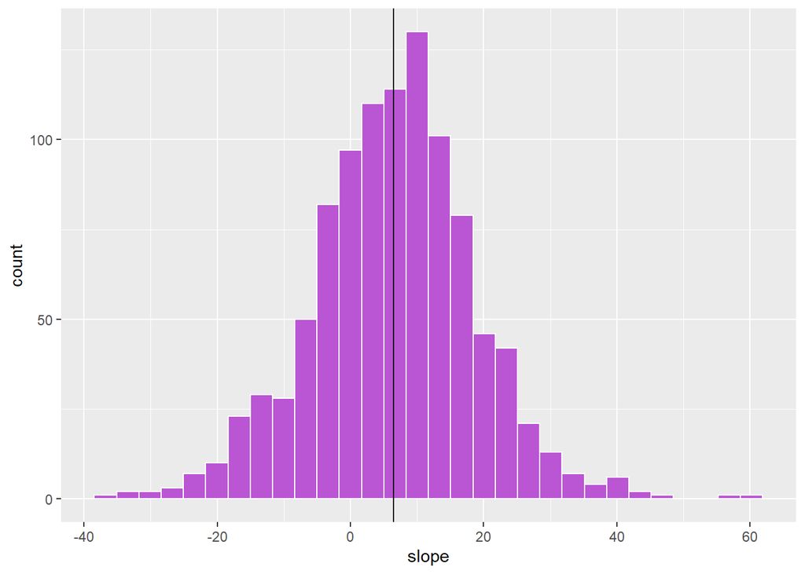

```r
relation <- tibble(student = names(slopes),
                   slope = slopes)

ggplot(relation, aes(slope)) +
  geom_histogram(fill = "mediumorchid",
                 color = "white") +
  geom_vline(aes(xintercept = mean(slope, na.rm = TRUE)))
```

# Part B: Star Wars

## Use the sw_films list to identify how many characters were represented in each film.

```r
#sw_films
length(sw_films)
```

```
## [1] 7
```

```r
#for only the first film
sw_films[[1]]$characters
```

```
##  [1] "http://swapi.co/api/people/1/"  "http://swapi.co/api/people/2/"
##  [3] "http://swapi.co/api/people/3/"  "http://swapi.co/api/people/4/"
##  [5] "http://swapi.co/api/people/5/"  "http://swapi.co/api/people/6/"
##  [7] "http://swapi.co/api/people/7/"  "http://swapi.co/api/people/8/"
##  [9] "http://swapi.co/api/people/9/"  "http://swapi.co/api/people/10/"
## [11] "http://swapi.co/api/people/12/" "http://swapi.co/api/people/13/"
## [13] "http://swapi.co/api/people/14/" "http://swapi.co/api/people/15/"
## [15] "http://swapi.co/api/people/16/" "http://swapi.co/api/people/18/"
## [17] "http://swapi.co/api/people/19/" "http://swapi.co/api/people/81/"
```

```r
length(sw_films[[1]]$characters)
```

```
## [1] 18
```

```r
#using map
chr_count <- map_dbl(sw_films, ~length(.x$characters))
chr_count
```

```
## [1] 18 40 34 34 20 16 11
```

```r
chr_names <- map_chr(sw_films, "title")
chr_names
```

```
## [1] "A New Hope"              "Attack of the Clones"
## [3] "The Phantom Menace"      "Revenge of the Sith"
## [5] "Return of the Jedi"      "The Empire Strikes Back"
## [7] "The Force Awakens"
```

```r
tibble(Film = chr_names,
              Characters = chr_count)
```

```
## # A tibble: 7 x 2
##   Film                    Characters
##   <chr>                        <dbl>
## 1 A New Hope                      18
## 2 Attack of the Clones            40
## 3 The Phantom Menace              34
## 4 Revenge of the Sith             34
## 5 Return of the Jedi              20
## 6 The Empire Strikes Back         16
## 7 The Force Awakens               11
```

## Use the sw_species list to (a) identify species that have known hair colors and (b) identify what those hair colors are.

```r
#str(sw_species)

hc <- map_chr(sw_species, "hair_colors")
hc
```

```
##  [1] "n/a"                       "brown, white"
##  [3] "none"                      "none"
##  [5] "white, brown, black"       "none"
##  [7] "none"                      "none"
##  [9] "none"                      "none"
## [11] "none"                      "none"
## [13] "none"                      "none"
## [15] "none"                      "red, blond, black, white"
## [17] "none"                      "black"
## [19] "unknown"                   "none"
## [21] "none"                      "none"
## [23] "none"                      "none"
## [25] "black, brown"              "none"
## [27] "none"                      "none"
## [29] "none"                      "none"
## [31] "none"                      "none"
## [33] "none"                      "black, brown"
## [35] "n/a"                       "blonde, brown, black, red"
## [37] "n/a"
```

```r
species <- map_chr(sw_species, "name")
species
```

```
##  [1] "Hutt"           "Yoda's species" "Trandoshan"     "Mon Calamari"
##  [5] "Ewok"           "Sullustan"      "Neimodian"      "Gungan"
##  [9] "Toydarian"      "Dug"            "Twi'lek"        "Aleena"
## [13] "Vulptereen"     "Xexto"          "Toong"          "Cerean"
## [17] "Nautolan"       "Zabrak"         "Tholothian"     "Iktotchi"
## [21] "Quermian"       "Kel Dor"        "Chagrian"       "Geonosian"
## [25] "Mirialan"       "Clawdite"       "Besalisk"       "Kaminoan"
## [29] "Skakoan"        "Muun"           "Togruta"        "Kaleesh"
## [33] "Pau'an"         "Wookiee"        "Droid"          "Human"
## [37] "Rodian"
```

```r
tbl2 <- tibble(Species = species,
       `Hair Colors` = hc) %>%
  filter(`Hair Colors` != "n/a" &
           `Hair Colors` != "none" &
           `Hair Colors` != "unknown")
tbl2
```

```
## # A tibble: 7 x 2
##   Species        `Hair Colors`
##   <chr>          <chr>
## 1 Yoda's species brown, white
## 2 Ewok           white, brown, black
## 3 Cerean         red, blond, black, white
## 4 Zabrak         black
## 5 Mirialan       black, brown
## 6 Wookiee        black, brown
## 7 Human          blonde, brown, black, red
```

# Part C: Some basic API calls

Pokemon example

```r
library(httr)
ability1 <- GET("https://pokeapi.co/api/v2/ability/1") %>%
    content("parsed")

attributes(ability1)
```

```
## $names
## [1] "effect_changes"      "effect_entries"      "flavor_text_entries"
## [4] "generation"          "id"                  "is_main_series"
## [7] "name"                "names"               "pokemon"
```

```r
#str(ability1)

#name of the ability
ability1$name
```

```
## [1] "stench"
```

```r
#number of pokemon with this ability
length(ability1$pokemon)
```

```
## [1] 7
```

Use {purrr} to write an API call to obtain data on the first five abilities (note, we’re only using the first five to make the calls go fast, but the code would be essentially equivalent for any number of abilities you wanted to query). Make sure you parse the JSON data to a list.

### API call for first five abilities

```r
abilities <- paste0("https://pokeapi.co/api/v2/ability/", 1:5)
abilities
```

```
## [1] "https://pokeapi.co/api/v2/ability/1" "https://pokeapi.co/api/v2/ability/2"
## [3] "https://pokeapi.co/api/v2/ability/3" "https://pokeapi.co/api/v2/ability/4"
## [5] "https://pokeapi.co/api/v2/ability/5"
```

```r
abs <- map(abilities, ~GET(.x) %>%
      content("parsed"))

#abs
```

### Data frame of given ability and pokemon with that ability

Use the parsed data to create a data frame that has the given ability, and the number of pokemon with that ability.

```r
ability <- map_chr(abs, "name")

#extract length for 1 list
length(abs[[1]]$pokemon)
```

```
## [1] 7
```

```r
#convert into map
count <- map(abs, list("pokemon")) %>%
  map_dbl(~length(.x))

#another way to coutn # of pokemon with each ability:
map_dbl(abs, ~length(.x$pokemon))
```

```
## [1]  7  3 12  9 42
```

```r
#create tibble
tibble(Ability = str_to_title(ability),
              `Number of Pokemon` = count)
```

```
## # A tibble: 5 x 2
##   Ability      `Number of Pokemon`
##   <chr>                      <dbl>
## 1 Stench                         7
## 2 Drizzle                        3
## 3 Speed-Boost                   12
## 4 Battle-Armor                   9
## 5 Sturdy                        42
```

# Bonus: Up to 1 point extra credit

Create a new data frame that lists the names of the pokemon with these specific abilities.

**Stephanie comment**: my group and I attempted the bonus but I was not able to get the map function to work to loop through to extract all the names of the pokemon for each ability. The following is the code we came up with thus far.

```r
#extract name of 1 pokemon from original list of 5 abilities
abs[[1]]$pokemon[[1]]$pokemon$name
```

```
## [1] "gloom"
```

```r
abs[[1]]$pokemon[[2]]$pokemon$name
```

```
## [1] "grimer"
```

```r
#another way to extract name of 1 pokemon
abs[[1]][["pokemon"]][[1]][["pokemon"]][["name"]]
```

```
## [1] "gloom"
```

```r
abs[[1]][["pokemon"]][[2]][["pokemon"]][["name"]]
```

```
## [1] "grimer"
```

```r
#extract 1 pokemon list and 1 ability
by_pokemon <- map(abs, "pokemon")
stench <- by_pokemon[1]

#extract individual level
pokemon1 <- by_pokemon[[1]][1]
pokemon1[[1]]$pokemon$name
```

```
## [1] "gloom"
```

```r
pokemon1[[1]][["pokemon"]][["name"]]
```

```
## [1] "gloom"
```